# MATH2319 Machine Learning - Course Project

#### Apppend target feature with encoded dataset and remove className column

```python
# Apppend target feature with encoded dataset and remove className column
df_encoding = df_encoding.assign(target = target.values)
df_encoding = df_encoding.drop(columns = ["className"])
df_encoding
```

|  | isHandicappedInfant | waterProjectCostSharing | adoptionBudgetResolution | physicianFeeFreeze | elSalvadorAid | religiousGroup | antiSatelliteBan | aidToNicaraguanContras | mxMissile | immigration | synfuelsCorporationCutback | educationSpending | superfundRightToSue | crime | dutyFreeExports | explortAdminActSA | target |
| --- | --- | --- | --- | --- | --- | --- | --- | --- | --- | --- | --- | --- | --- | --- | --- | --- | --- |
| 0 | 0 | 1 | 0 | 1 | 1 | 1 | 0 | 0 | 0 | 1 | 0 | 1 | 1 | 1 | 0 | 1 | 1 |
| 1 | 0 | 1 | 0 | 1 | 1 | 1 | 0 | 0 | 0 | 0 | 0 | 1 | 1 | 1 | 0 | 1 | 1 |
| 2 | 0 | 1 | 1 | 0 | 1 | 1 | 0 | 0 | 0 | 0 | 1 | 0 | 1 | 1 | 0 | 0 | 0 |
| 3 | 0 | 1 | 1 | 0 | 1 | 1 | 0 | 0 | 0 | 0 | 1 | 0 | 1 | 0 | 0 | 1 | 0 |
| 4 | 1 | 1 | 1 | 0 | 1 | 1 | 0 | 0 | 0 | 0 | 1 | 0 | 1 | 1 | 1 | 1 | 0 |
| ... | ... | ... | ... | ... | ... | ... | ... | ... | ... | ... | ... | ... | ... | ... | ... | ... | ... |
| 430 | 0 | 0 | 1 | 1 | 1 | 1 | 0 | 0 | 1 | 1 | 0 | 1 | 1 | 1 | 0 | 1 | 1 |
| 431 | 0 | 0 | 1 | 0 | 0 | 0 | 1 | 1 | 1 | 1 | 0 | 0 | 0 | 0 | 0 | 1 | 0 |
| 432 | 0 | 1 | 0 | 1 | 1 | 1 | 0 | 0 | 0 | 0 | 1 | 1 | 1 | 1 | 0 | 1 | 1 |
| 433 | 0 | 0 | 0 | 1 | 1 | 1 | 1 | 1 | 1 | 1 | 0 | 1 | 1 | 1 | 0 | 1 | 1 |
| 434 | 0 | 1 | 0 | 1 | 1 | 1 | 0 | 0 | 0 | 1 | 0 | 1 | 1 | 1 | 0 | 0 | 1 |

435 rows × 17 columns

#### Summary Stats:

```python
# Summary statistics of encoded dataset
df_encoding.describe().round(0)
```

|  | isHandicappedInfant | waterProjectCostSharing | adoptionBudgetResolution | physicianFeeFreeze | elSalvadorAid | religiousGroup | antiSatelliteBan | aidToNicaraguanContras | mxMissile | immigration | synfuelsCorporationCutback | educationSpending | superfundRightToSue | crime | dutyFreeExports | explortAdminActSA | target |
| --- | --- | --- | --- | --- | --- | --- | --- | --- | --- | --- | --- | --- | --- | --- | --- | --- | --- |
| count | 435.0 | 435.0 | 435.0 | 435.0 | 435.0 | 435.0 | 435.0 | 435.0 | 435.0 | 435.0 | 435.0 | 435.0 | 435.0 | 435.0 | 435.0 | 435.0 | 435.0 |
| mean | 0.0 | 1.0 | 1.0 | 0.0 | 1.0 | 1.0 | 1.0 | 1.0 | 1.0 | 1.0 | 0.0 | 0.0 | 1.0 | 1.0 | 0.0 | 1.0 | 0.0 |
| std | 0.0 | 0.0 | 0.0 | 0.0 | 1.0 | 0.0 | 0.0 | 0.0 | 0.0 | 1.0 | 0.0 | 0.0 | 0.0 | 0.0 | 0.0 | 0.0 | 0.0 |
| min | 0.0 | 0.0 | 0.0 | 0.0 | 0.0 | 0.0 | 0.0 | 0.0 | 0.0 | 0.0 | 0.0 | 0.0 | 0.0 | 0.0 | 0.0 | 0.0 | 0.0 |
| 25% | 0.0 | 0.0 | 0.0 | 0.0 | 0.0 | 0.0 | 0.0 | 0.0 | 0.0 | 0.0 | 0.0 | 0.0 | 0.0 | 0.0 | 0.0 | 1.0 | 0.0 |
| 50% | 0.0 | 1.0 | 1.0 | 0.0 | 1.0 | 1.0 | 1.0 | 1.0 | 1.0 | 1.0 | 0.0 | 0.0 | 1.0 | 1.0 | 0.0 | 1.0 | 0.0 |
| 75% | 1.0 | 1.0 | 1.0 | 1.0 | 1.0 | 1.0 | 1.0 | 1.0 | 1.0 | 1.0 | 1.0 | 1.0 | 1.0 | 1.0 | 1.0 | 1.0 | 1.0 |
| max | 1.0 | 1.0 | 1.0 | 1.0 | 1.0 | 1.0 | 1.0 | 1.0 | 1.0 | 1.0 | 1.0 | 1.0 | 1.0 | 1.0 | 1.0 | 1.0 | 1.0 |

```python
# Summary statistics of target feature
target.describe(include ='int64')
```

```
count    435.000000
mean       0.386207
std        0.487440
min        0.000000
25%        0.000000
50%        0.000000
75%        1.000000
max        1.000000
Name: className, dtype: float64
```

## Data Exploration

After cleaning dataset, we are good for data exploration.

### Data Exploration 1 - Count of each target feature (Class Name)

Histogram is suitable for count if each target value.

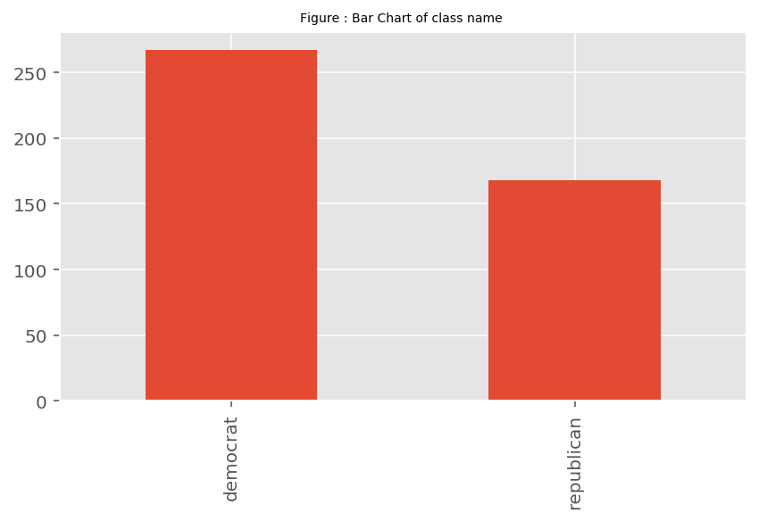

```python
df_explore = df_encoding.copy()
df_explore['target'] = df_explore['target'].replace({0:'democrat',1:'republican'})
ax = df_explore['target'].value_counts().plot(kind = 'bar')
ax.set_xticklabels(ax.get_xticklabels(), rotation = 90)
plt.tight_layout()
plt.title('Figure : Bar Chart of class name ', fontsize = 7)
plt.show()
```

### Data Exploration 2 - Each key votes by target (Class Name)

Our dataset has Y/N data in features. So bar plot is suitable. Each bar plot represent count of Yes/No by each key votes for each target value. Each distribution party is different then other with each key votes.

Plot has separate table at x-axis for adequate value for each target.

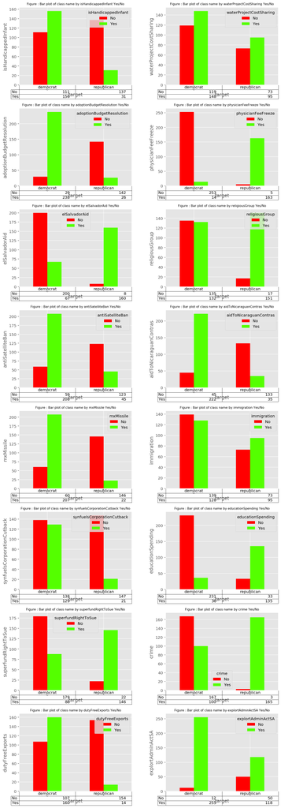

```python
#Code goes after this line by adding cells
col_count = 2
row_count = math.ceil((len(df_col)-1) / col_count)

fig, axes = plt.subplots(row_count, col_count, figsize=(5*col_count,5*row_count))
fig.tight_layout() # Or equivalently,  "plt.tight_layout()"
plt.subplots_adjust(bottom=0.2, top=0.9, wspace=0.3, hspace=0.3)
df_explore = df_encoding.copy()
df_explore['target'] = df_explore['target'].replace({0:'democrat',1:'republican'})
n = 0
for i in df_col:
    if i != 'className':
        df_aggr = df_explore[['target', i]].groupby([i,'target']).size().reset_index()
        df_aggr[i] = df_aggr[i].replace({0:'No',1:'Yes'})
        df_aggr1 = df_aggr.pivot(index='target', columns=i, values=0)
        # print("")
        df_aggr1.plot(kind='bar', color = (yes_no_colors.values()), table=True,ax=fig.axes[n])
        fig.axes[n].set_xticklabels('Class Name', rotation= 45, fontsize = 7)
        fig.axes[n].set_ylabel(i)
        fig.axes[n].set_title('Figure : Bar plot of class name by {0} Yes/No'.format(i), fontsize=8)
        n = n + 1
# plt.show()
```

### Data Exploration 3 - Count of voter for each class name by key votes

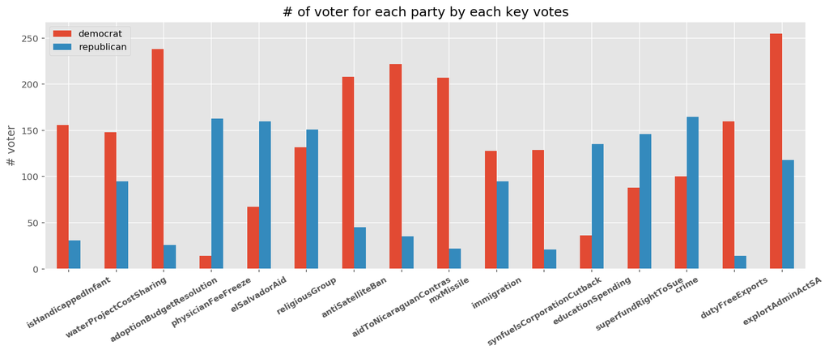

```python
df_explore_1 = df_explore.groupby('target').sum().reset_index()
df_explore_1_1 = df_explore_1.transpose().reset_index()
df_explore_1_1 = df_explore_1_1[1:]
df_explore_1_1 = df_explore_1_1.rename(columns = {'index':'feature', 0:'democrat',1:'republican'})

fig, axs = plt.subplots(1, 1, figsize=(15,5))

df_explore_1_1.plot(kind='bar',ax=fig.axes[0])
fig.axes[0].set_xticklabels(labels=df_explore_1_1['feature'], rotation= 30, fontsize = 9, fontweight='bold')
fig.axes[0].set_ylabel("# voter")
fig.axes[0].set_title("# of voter for each party by each key votes")
```

```python
df_final = df_encoding.copy()
target = df_final.pop('target')
```

```python
df_final
```

|  | isHandicappedInfant | waterProjectCostSharing | adoptionBudgetResolution | physicianFeeFreeze | elSalvadorAid | religiousGroup | antiSatelliteBan | aidToNicaraguanContras | mxMissile | immigration | synfuelsCorporationCutback | educationSpending | superfundRightToSue | crime | dutyFreeExports | explortAdminActSA |
| --- | --- | --- | --- | --- | --- | --- | --- | --- | --- | --- | --- | --- | --- | --- | --- | --- |
| 0 | 0 | 1 | 0 | 1 | 1 | 1 | 0 | 0 | 0 | 1 | 0 | 1 | 1 | 1 | 0 | 1 |
| 1 | 0 | 1 | 0 | 1 | 1 | 1 | 0 | 0 | 0 | 0 | 0 | 1 | 1 | 1 | 0 | 1 |
| 2 | 0 | 1 | 1 | 0 | 1 | 1 | 0 | 0 | 0 | 0 | 1 | 0 | 1 | 1 | 0 | 0 |
| 3 | 0 | 1 | 1 | 0 | 1 | 1 | 0 | 0 | 0 | 0 | 1 | 0 | 1 | 0 | 0 | 1 |
| 4 | 1 | 1 | 1 | 0 | 1 | 1 | 0 | 0 | 0 | 0 | 1 | 0 | 1 | 1 | 1 | 1 |
| ... | ... | ... | ... | ... | ... | ... | ... | ... | ... | ... | ... | ... | ... | ... | ... | ... |
| 430 | 0 | 0 | 1 | 1 | 1 | 1 | 0 | 0 | 1 | 1 | 0 | 1 | 1 | 1 | 0 | 1 |
| 431 | 0 | 0 | 1 | 0 | 0 | 0 | 1 | 1 | 1 | 1 | 0 | 0 | 0 | 0 | 0 | 1 |
| 432 | 0 | 1 | 0 | 1 | 1 | 1 | 0 | 0 | 0 | 0 | 1 | 1 | 1 | 1 | 0 | 1 |
| 433 | 0 | 0 | 0 | 1 | 1 | 1 | 1 | 1 | 1 | 1 | 0 | 1 | 1 | 1 | 0 | 1 |
| 434 | 0 | 1 | 0 | 1 | 1 | 1 | 0 | 0 | 0 | 1 | 0 | 1 | 1 | 1 | 0 | 0 |

435 rows × 16 columns

# Predictive Modelling:

```
- In this part we are going to apply 4 predictive modeling algorithms for (binary) classification.
- We are going to implement following algorithms:

    1) KNN(k-nearest neighbors) Algorithm
    2) Naive Bays Algorithm
    3) Decision Tree Algorithm
    4) Support Vector Classification Algorithm

- Here, we will be using classification algorithms rather than regression algorithms as it suits our dataset and setting categorical variable as target variable.
- We will split our dataset; 75% for training and 25% for testing randomly.
- Hypermeter Tuning; We will use different parameters like:

      (i) n_neighbors, p_value for KNN algorithm.
     (ii) 3 different models (Gaussian, Bernaulli and Complement) for Naive Bays Algorithm.
    (iii) max_depth, min_samples_split, min_samples_leaf and max_features for Decision Tree Algorithm.
     (iv) kernal, c_value and gamma for Support Vector Classifier.

 - We further performed paired t-test with best tuned hyperparameter accuracy with other algorithms.
```

## Model Evaluation Strategy:

```
   - We will use AUC Score for model evaluation for each iteration of tuned parameter.
```

## KNN Implementation

```
- KNN algorithm is supervised machine learning algorithm based on distance from proximity.
- It is one of the most common yet powerful algorithm.
```

```python
# Importing libraries
from sklearn.neighbors import KNeighborsClassifier
from sklearn.metrics import accuracy_score, roc_curve, auc
```

```python
# Spliting the dataset:

from sklearn.model_selection import train_test_split

x_train, x_test, y_train, y_test = train_test_split(df_final, target, test_size=0.25, random_state=0)
```

```python
# Fitting and Predicting the model

knn = KNeighborsClassifier()
knn.fit(x_train, y_train)
y_pred = knn.predict(x_test)
```

#### KNN baseline Evaluation using default parameters:

```python
from sklearn.metrics import roc_curve, auc

false_positive_rate, true_positive_rate, thresholds = roc_curve(y_test, y_pred)
roc_auc = auc(false_positive_rate, true_positive_rate)
print("KNN Baseline Evaluation using default parameters:")
print("------------------------------------------------")
print("AUC Score", roc_auc.round(6))
acc_per = round(roc_auc*100, 3)
print('\033[1m' + "Accuracy:" + str(acc_per), "%" )
```

```
KNN Baseline Evaluation using default parameters:
------------------------------------------------
AUC Score 0.931119
Accuracy:93.112 %
```

## KNN Hyperparameter Tuning

```
1. No. of Neighbor
2. P-value (distance metric)
```

#### Hyperparameter(1) Tuning - No. of Neighbors

```python
neighbors = list(range(1,30))
train_results = []
test_results = []
for n in neighbors:
    knn = KNeighborsClassifier(n_neighbors=n)
    knn.fit(x_train, y_train)
    train_pred = knn.predict(x_train)
    false_positive_rate, true_positive_rate, thresholds = roc_curve(y_train, train_pred)
    roc_auc = auc(false_positive_rate, true_positive_rate)
    train_results.append(roc_auc)
    y_pred = knn.predict(x_test)
    false_positive_rate, true_positive_rate, thresholds = roc_curve(y_test, y_pred)
    roc_auc = auc(false_positive_rate, true_positive_rate)
    test_results.append(roc_auc)

best_results_knn = test_results
```

```python
x = test_results.index(max(test_results))
print("Optimal AUC Score:", max(test_results))
optimal_auc_knn_n = max(test_results)
opt_n = neighbors[x]
print("Optimal Neighbors:", opt_n)
```

```
Optimal AUC Score: 0.938811188811189
Optimal Neighbors: 6
```

```python
knn = KNeighborsClassifier(n_neighbors=opt_n)
knn.fit(x_train, y_train)
y_knn_pred = knn.predict(x_test)
```

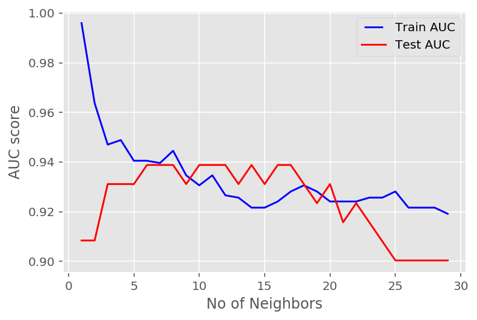

```python
from matplotlib.legend_handler import HandlerLine2D

line1, = plt.plot(neighbors, train_results, "b", label="Train AUC")
line2, = plt.plot(neighbors, test_results, "r", label="Test AUC")
plt.legend(handler_map={line1: HandlerLine2D(numpoints=2)})
plt.ylabel('AUC score')
plt.xlabel('No of Neighbors')
plt.show()
```

#### Hyperparameter(2) P-Value in Minkowski Distance

```
When p=1 -> Equivalent Manhattan Distance
     p=2 -> Equivalent Euclidian Distance
     p=3,4,5 -> Arbitary p-value in Minkowski Distance
```

```python
P_values = [1, 2, 3, 4, 5]
train_results = []
test_results = []
for p_value in P_values:
    knn = KNeighborsClassifier(p=p_value)
    knn.fit(x_train, y_train)
    train_pred = knn.predict(x_train)
    false_positive_rate, true_positive_rate, thresholds = roc_curve(y_train, train_pred)
    roc_auc = auc(false_positive_rate, true_positive_rate)
    train_results.append(roc_auc)
    y_pred = knn.predict(x_test)
    false_positive_rate, true_positive_rate, thresholds = roc_curve(y_test, y_pred)
    roc_auc = auc(false_positive_rate, true_positive_rate)
    test_results.append(roc_auc)
```

```python
x = test_results.index(max(test_results))
optimal_auc_knn_p =  max(test_results)
print("Optimal AUC Score:", max(test_results))
opt_p = P_values[x]
print("Optimal P_value:", opt_p)
```

```
Optimal AUC Score: 0.9311188811188811
Optimal P_value: 1
```

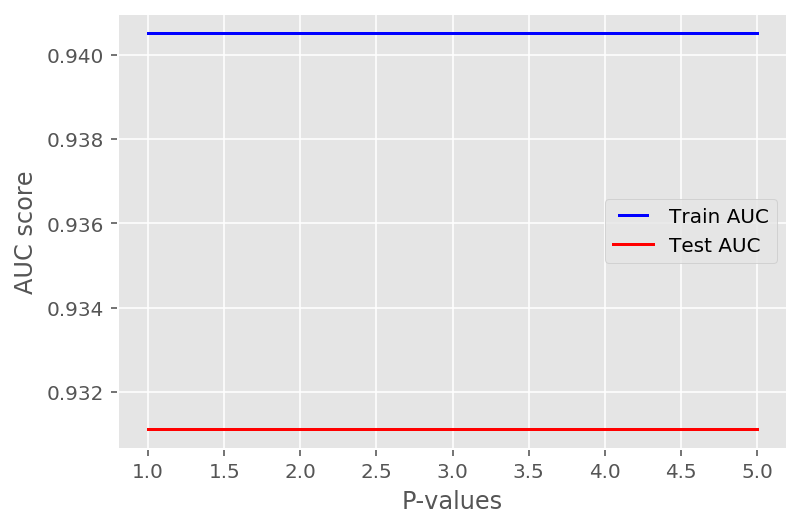

```python
from matplotlib.legend_handler import HandlerLine2D

line1, = plt.plot(P_values, train_results, "b", label="Train AUC")
line2, = plt.plot(P_values, test_results, "r", label="Test AUC")
plt.legend(handler_map={line1: HandlerLine2D(numpoints=2)})
plt.ylabel("AUC score")
plt.xlabel("P-values")
plt.show()
```

## KNN Evaluation Report

```python
print()
print('\033[1m' + "KNN Classification Algorithm with Optimal Hyperparameter Configuration")
print("-----------------------------------------------------------------------")

print("|" , "Optimal No of Neighbor" , ":" , opt_n, "|")
print("|",  "Optimal P-Value", "       :", opt_p, "|")
print("|", "Optimal Accuracy", ":", round(optimal_auc_knn_n*100,2), "%", "|")
```

```
KNN Classification Algorithm with Optimal Hyperparameter Configuration
-----------------------------------------------------------------------
| Optimal No of Neighbor : 6 |
| Optimal P-Value        : 1 |
| Optimal Accuracy : 93.88 % |
```

```
- Here we can see we got highest Accuracy with No of neighbors = 6 and P-value = 1 as 93.88%
```

## Naive Bays Algorithm Implementation

#### Gaussian Model

```
 -> It is used in classification and it assumes that features follow a normal distribution.
```

```python
# importing required libraries
from sklearn.naive_bayes import GaussianNB
from sklearn.metrics import accuracy_score
```

```python
# Fitting and Predicting the model

gnb =  GaussianNB()
gnb.fit(x_train, y_train)
y_pred = gnb.predict(x_test)
```

```python
from sklearn.metrics import roc_curve, auc

false_positive_rate, true_positive_rate, thresholds = roc_curve(y_test, y_pred)
gnb_roc_auc = auc(false_positive_rate, true_positive_rate)
print("Gaussian Naive Bays - Baseline Evaluation using default parameters:")
print("------------------------------------------------")
print("AUC Score", gnb_roc_auc.round(6))
gnb_acc_per = round(gnb_roc_auc*100, 3)
print('\033[1m' + "Accuracy:" + str(gnb_acc_per), "%" )
```

```
Gaussian Naive Bays - Baseline Evaluation using default parameters:
------------------------------------------------
AUC Score 0.927448
Accuracy:92.745 %
```

```python
var_smoothing = np.logspace(1,-3, num=200)
train_results = []
test_results = []
for v in var_smoothing:
    gnb =  GaussianNB(var_smoothing = v)
    gnb.fit(x_train, y_train)
    train_pred = gnb.predict(x_train)
    false_positive_rate, true_positive_rate, thresholds = roc_curve(y_train, train_pred)
    roc_auc = auc(false_positive_rate, true_positive_rate)
    train_results.append(roc_auc)
    y_pred = knn.predict(x_test)
    false_positive_rate, true_positive_rate, thresholds = roc_curve(y_test, y_pred)
    roc_auc = auc(false_positive_rate, true_positive_rate)
    test_results.append(roc_auc)

best_results_nb = test_results
```

```python
gnb =  GaussianNB(var_smoothing = v)
gnb.fit(x_train, y_train)
y_nb_pred = gnb.predict(x_test)
```

#### Bernoulli Model

```
-> Naive Bayes classifier for multivariate Bernoulli models.
-> This classifier is suitable for discrete data.
-> BernoulliNB is designed for binary/boolean features.
```

```python
# importing required libraries

from sklearn.naive_bayes import BernoulliNB
```

```python
# Fitting and Predicting the model

bnb = BernoulliNB()
bnb.fit(x_train, y_train)
y_pred = bnb.predict(x_test)
```

```python
false_positive_rate, true_positive_rate, thresholds = roc_curve(y_test, y_pred)
bnb_roc_auc = auc(false_positive_rate, true_positive_rate)
print("Bernoulli Naive Bays - Baseline Evaluation using default parameters:")
print("--------------------------------------------------------------------")
print("AUC Score", bnb_roc_auc.round(6))
bnb_acc_per = round(bnb_roc_auc*100, 3)
print('\033[1m' + "Accuracy:" + str(bnb_acc_per), "%" )
```

```
Bernoulli Naive Bays - Baseline Evaluation using default parameters:
--------------------------------------------------------------------
AUC Score 0.90035
Accuracy:90.035 %
```

#### Complement Model

```
-> This was designed to correct the “severe assumptions” made by the standard Multinomial Naive Bayes classifier.
-> It is particularly suited for imbalanced data sets.
```

```python
# importing required libraries

from sklearn.naive_bayes import ComplementNB
```

```python
cnb = ComplementNB()
cnb.fit(x_train, y_train)
y_pred = cnb.predict(x_test)
```

```python
false_positive_rate, true_positive_rate, thresholds = roc_curve(y_test, y_pred)
cnb_roc_auc = auc(false_positive_rate, true_positive_rate)
print("Complement Naive Bays - Baseline Evaluation using default parameters:")
print("--------------------------------------------------------------------")
print("AUC Score", cnb_roc_auc.round(6))
cnb_acc_per = round(cnb_roc_auc*100, 3)
print('\033[1m' + "Accuracy:" + str(cnb_acc_per), "%" )
```

```
Complement Naive Bays - Baseline Evaluation using default parameters:
--------------------------------------------------------------------
AUC Score 0.90035
Accuracy:90.035 %
```

## Naive Bays Evaluation Report:

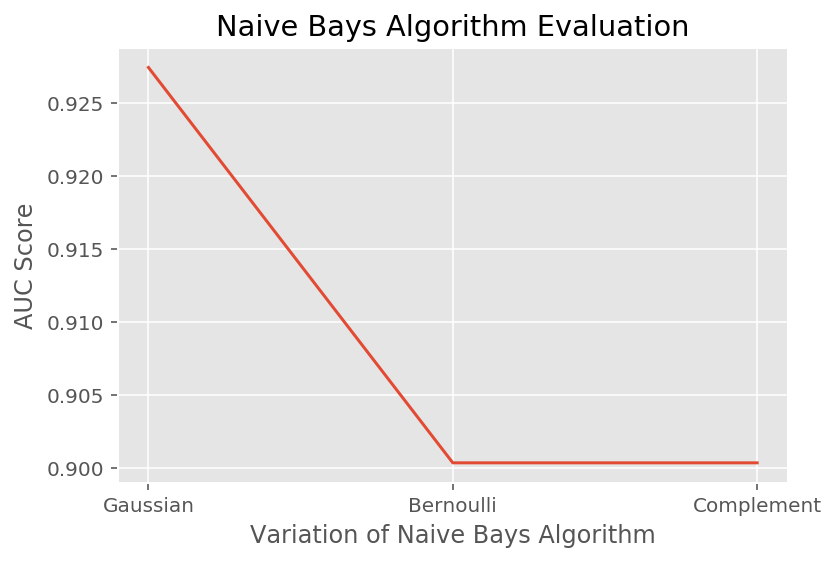

```python
scores = [gnb_roc_auc, bnb_roc_auc, cnb_roc_auc]
scores
nb_algo = ["Gaussian", "Bernoulli", "Complement"]
plt.plot(nb_algo, scores)
plt.title("Naive Bays Algorithm Evaluation")
plt.xlabel("Variation of Naive Bays Algorithm")
plt.ylabel("AUC Score")
plt.show()

optinmal_auc_nb = max(scores)
index = scores.index(optinmal_auc_nb)
optimal_model = nb_algo[index]
```

```python
print()
print('\033[1m' + "Naive Bays Classification Algorithm with Optimal Hyperparameter Configuration")
print("-----------------------------------------------------------------------")

print("|" , "Optimal Model" , "   :" , optimal_model, "|")
print("|", "Optimal Accuracy", ": ", round(optinmal_auc_nb*100,2), "%", "|")
```

```
Naive Bays Classification Algorithm with Optimal Hyperparameter Configuration
-----------------------------------------------------------------------
| Optimal Model    : Gaussian |
| Optimal Accuracy :  92.74 % |
```

```
- In Naive Bays Classification we observed Highest Accuracy of 92.74 % using Guassian Model.
```

## Decision Tree Implementation

```python
# importing required libraries
from sklearn.tree import DecisionTreeClassifier
```

```python
dt = DecisionTreeClassifier()
dt.fit(x_train, y_train)
y_pred = dt.predict(x_test)
```

#### Decision Tree Baseline Evaluation

```python
false_positive_rate, true_positive_rate, thresholds = roc_curve(y_test, y_pred)
dt_roc_auc = auc(false_positive_rate, true_positive_rate)
print("Decision Tree Classifier - Baseline Evaluation using default parameters:")
print("--------------------------------------------------------------------")
print("AUC Score", dt_roc_auc.round(6))
dt_acc_per = round(dt_roc_auc*100, 3)
print('\033[1m' + "Accuracy:" + str(dt_acc_per), "%" )
```

```
Decision Tree Classifier - Baseline Evaluation using default parameters:
--------------------------------------------------------------------
AUC Score 0.927448
Accuracy:92.745 %
```

## Decision Tree Classifier Hyperparameter Tuning

```
1. max_depth
2. min_samples_split
3. min_samples_leaf
4. max_features
```

### Hyperparameter(1) Tuning - Max Depth

```
   -> This indicates the depth of the tree.
   -> Deeper the tree, more it captures information about the data.
   -> Varing depth from 1 to 32 and plot the training and test auc scores.
```

```python
max_depths = np.linspace(1, 32, 32, endpoint=True)
train_results = []
test_results = []
for max_depth in max_depths:
    dt = DecisionTreeClassifier(max_depth=max_depth)
    dt.fit(x_train, y_train)
    train_pred = dt.predict(x_train)
    false_positive_rate, true_positive_rate, thresholds = roc_curve(y_train, train_pred)
    roc_auc = auc(false_positive_rate, true_positive_rate)
    # Add auc score to previous train results
    train_results.append(roc_auc)
    y_pred = dt.predict(x_test)
    false_positive_rate, true_positive_rate, thresholds = roc_curve(y_test, y_pred)
    roc_auc = auc(false_positive_rate, true_positive_rate)
    # Add auc score to previous test results
    test_results.append(roc_auc)

dt_scores =[]
dt_scores.append(max(test_results))
index = test_results.index(max(test_results))
optimal_dt_depth = int(max_depths[index])
optimal_auc_dt_depth = max(test_results)
best_results_dt = test_results
```

```python
dt = DecisionTreeClassifier(max_depth=max_depth)
dt.fit(x_train, y_train)
y_dt_pred = dt.predict(x_test)
```

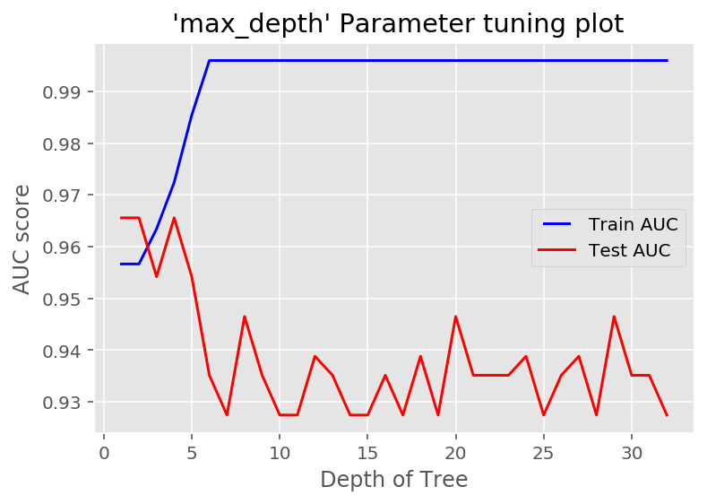

```python
from matplotlib.legend_handler import HandlerLine2D

line1, = plt.plot(max_depths, train_results, "b", label="Train AUC")
line2, = plt.plot(max_depths, test_results, "r", label="Test AUC")
plt.legend(handler_map={line1: HandlerLine2D(numpoints=2)})
plt.title(" 'max_depth' Parameter tuning plot")
plt.ylabel("AUC score")
plt.xlabel("Depth of Tree")
plt.show()
```

### Hyperparameter(2) Tuning - min_samples_split

```
   -> It represents the minimum number of samples required to split an internal node.
   -> By increasing this parameter, the tree becomes more constrained as it has to consider more samples at each node.
   -> Varing the parameter from 10% to 100% of the samples.
```

```python
min_samples_splits = np.linspace(0.1, 1.0, 10, endpoint=True)
train_results = []
test_results = []
for min_samples_split in min_samples_splits:
    dt = DecisionTreeClassifier(min_samples_split=min_samples_split)
    dt.fit(x_train, y_train)
    train_pred = dt.predict(x_train)
    false_positive_rate, true_positive_rate, thresholds =    roc_curve(y_train, train_pred)
    roc_auc = auc(false_positive_rate, true_positive_rate)
    train_results.append(roc_auc)
    y_pred = dt.predict(x_test)
    false_positive_rate, true_positive_rate, thresholds = roc_curve(y_test, y_pred)
    roc_auc = auc(false_positive_rate, true_positive_rate)
    test_results.append(roc_auc)

dt_scores.append(max(test_results))
index = test_results.index(max(test_results))
optimal_dt_split = int(max_depths[index])
optimal_auc_dt_split = max(test_results)
```

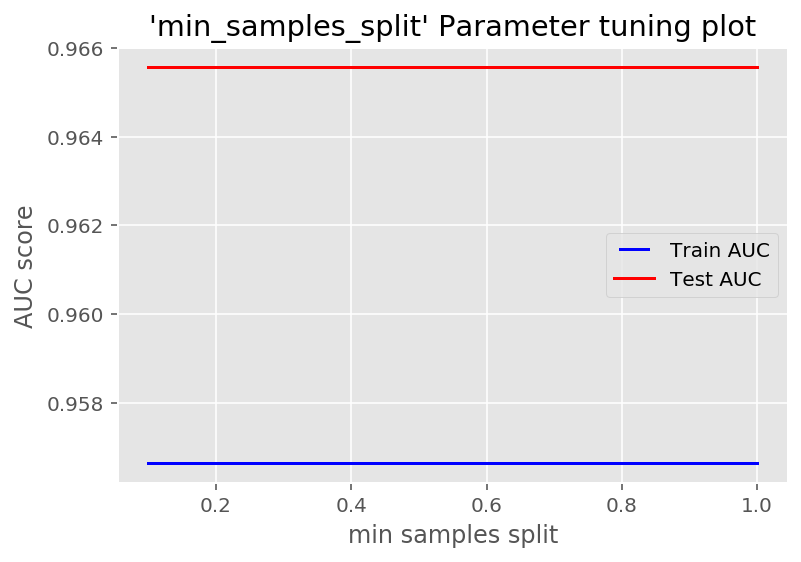

```python
from matplotlib.legend_handler import HandlerLine2D

line1, = plt.plot(min_samples_splits, train_results, "b", label="Train AUC")
line2, = plt.plot(min_samples_splits, test_results, "r", label="Test AUC")
plt.legend(handler_map={line1: HandlerLine2D(numpoints=2)})
plt.title("'min_samples_split' Parameter tuning plot")
plt.ylabel("AUC score")
plt.xlabel("min samples split" )
plt.show()
```

### Hyperparameter(3) Tuning - min_samples_leaf

```
    -> It is the minimum number of samples required at a leaf node.
```

```python
min_samples_leafs = np.linspace(0.1, 0.5, 5, endpoint=True)
train_results = []
test_results = []

for min_samples_leaf in min_samples_leafs:
    dt = DecisionTreeClassifier(min_samples_leaf=min_samples_leaf)
    dt.fit(x_train, y_train)
    train_pred = dt.predict(x_train)
    false_positive_rate, true_positive_rate, thresholds = roc_curve(y_train, train_pred)
    roc_auc = auc(false_positive_rate, true_positive_rate)
    train_results.append(roc_auc)
    y_pred = dt.predict(x_test)
    false_positive_rate, true_positive_rate, thresholds = roc_curve(y_test, y_pred)
    roc_auc = auc(false_positive_rate, true_positive_rate)
    test_results.append(roc_auc)

dt_scores.append(max(test_results))
index = test_results.index(max(test_results))
optimal_dt_leaf = (min_samples_leafs[index])
optimal_auc_dt_leaf = max(test_results)
```

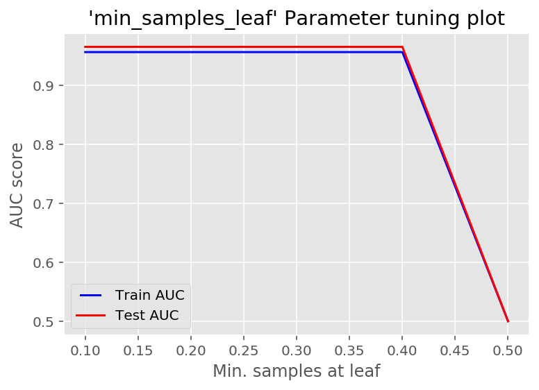

```python
from matplotlib.legend_handler import HandlerLine2D

line1, = plt.plot(min_samples_leafs, train_results, "b", label="Train AUC")
line2, = plt.plot(min_samples_leafs, test_results, "r", label="Test AUC")
plt.legend(handler_map={line1: HandlerLine2D(numpoints=2)})
plt.title("'min_samples_leaf' Parameter tuning plot")
plt.ylabel("AUC score")
plt.xlabel("Min. samples at leaf")
plt.show()
```

### Hyperparameter(4) Tuning - max_features

```
    ->  It represents the number of features to consider when looking for the best split.
```

```python
max_features = list(range(1,df_final.shape[1]))
train_results = []
test_results = []

for max_feature in max_features:
    dt = DecisionTreeClassifier(max_features=max_feature)
    dt.fit(x_train, y_train)
    train_pred = dt.predict(x_train)
    false_positive_rate, true_positive_rate, thresholds = roc_curve(y_train, train_pred)
    roc_auc = auc(false_positive_rate, true_positive_rate)
    train_results.append(roc_auc)
    y_pred = dt.predict(x_test)
    false_positive_rate, true_positive_rate, thresholds = roc_curve(y_test, y_pred)
    roc_auc = auc(false_positive_rate, true_positive_rate)
    test_results.append(roc_auc)

dt_scores.append(max(test_results))
index = test_results.index(max(test_results))
optimal_dt_feat = (max_features[index])
optimal_auc_dt_feat = max(test_results)
```

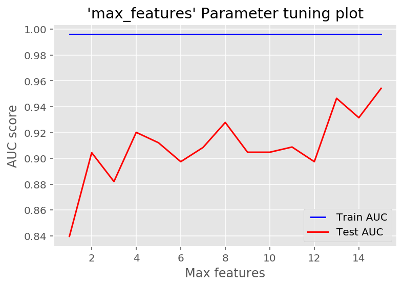

```python
from matplotlib.legend_handler import HandlerLine2D

line1, = plt.plot(max_features, train_results, "b", label="Train AUC")
line2, = plt.plot(max_features, test_results, "r", label="Test AUC")
plt.legend(handler_map={line1: HandlerLine2D(numpoints=2)})
plt.title("'max_features' Parameter tuning plot")
plt.ylabel("AUC score")
plt.xlabel("Max features")
plt.show()
```

## Decision Tree Evaluation Report

```python
print()
print('\033[1m' + "Decision Tree Classification Algorithm with Optimal Hyperparameter Configuration")
print("-----------------------------------------------------------------------")

print("|" , "Optimal Depth" , "       :", optimal_dt_depth ,   "  |", round(optimal_auc_dt_depth*100, 2),'%', "|")
print("|", "Optimal Sample Split", ":", optimal_dt_split, "  |", round(optimal_auc_dt_split*100,2),"%",  "|")
print("|", "Optimal Sample Leaf", " :",optimal_dt_leaf , "|", round(optimal_auc_dt_leaf*100, 2),"%",  "|")
print("|", "Optimal Features", " :",optimal_dt_feat , " |", round(optimal_auc_dt_feat*100, 2),"%",  " |")
```

```
Decision Tree Classification Algorithm with Optimal Hyperparameter Configuration
-----------------------------------------------------------------------
| Optimal Depth        : 1   | 96.56 % |
| Optimal Sample Split : 1   | 96.56 % |
| Optimal Sample Leaf  : 0.1 | 96.56 % |
| Optimal Features  : 15  | 95.42 %  |
```

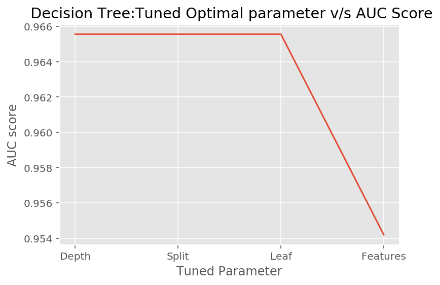

```python
plt.plot(["Depth","Split","Leaf","Features"],dt_scores)
plt.xlabel("Tuned Parameter")
plt.ylabel("AUC score")
plt.title(" Decision Tree:Tuned Optimal parameter v/s AUC Score")
plt.show()
```

```
 - In Decision Tree Algorith we observed highest accuracy of 96.56% with Depth = 1, Sample Split = 1, Sample Leaf = 0.1 and default no. of featues.
```

## Support Vector Machine Implementation

```python
# importing required libraries
from sklearn.svm import SVC
```

```python
svc = SVC()
svc.fit(x_train, y_train)
y_pred = svc.predict(x_test)
```

#### SVC Baseline Evaluation:

```python
false_positive_rate, true_positive_rate, thresholds = roc_curve(y_test, y_pred)
svc_roc_auc = auc(false_positive_rate, true_positive_rate)
print("Support Vector Classifier - Baseline Evaluation using default parameters:")
print("--------------------------------------------------------------------")
print("AUC Score", svc_roc_auc.round(6))
svc_acc_per = round(svc_roc_auc*100, 3)
print('\033[1m' + "Accuracy:" + str(svc_acc_per), "%" )
```

```
Support Vector Classifier - Baseline Evaluation using default parameters:
--------------------------------------------------------------------
AUC Score 0.965559
Accuracy:96.556 %
```

## Support Vector Classifier Hyperparameter Tuning

```
1. Kernel.
2. C Value.
3. Gamma.
```

#### Hyperparameter(1) Tuning - Kernel

```
-> It is a method of solving nonlinear classifier linearly.
    Default value: 'rbf' ; Radial Basis Function (RBF)
    Changed Value: 'poly'; Polynomial Function (POLY)
```

```python
svc = SVC(kernel="poly")
svc.fit(x_train, y_train)
y_pred = svc.predict(x_test)
```

```python
false_positive_rate, true_positive_rate, thresholds = roc_curve(y_test, y_pred)
poly_roc_auc = auc(false_positive_rate, true_positive_rate)
print("Support Vector Classifier - 'poly' kernel function Evaluation:")
print("--------------------------------------------------------------------")
print("AUC Score", poly_roc_auc.round(6))
poly_acc_per = round(poly_roc_auc*100, 3)
print('\033[1m' + "Accuracy:" + str(poly_acc_per), "%" )
```

```
Support Vector Classifier - 'poly' kernel function Evaluation:
--------------------------------------------------------------------
AUC Score 0.946503
Accuracy:94.65 %
```

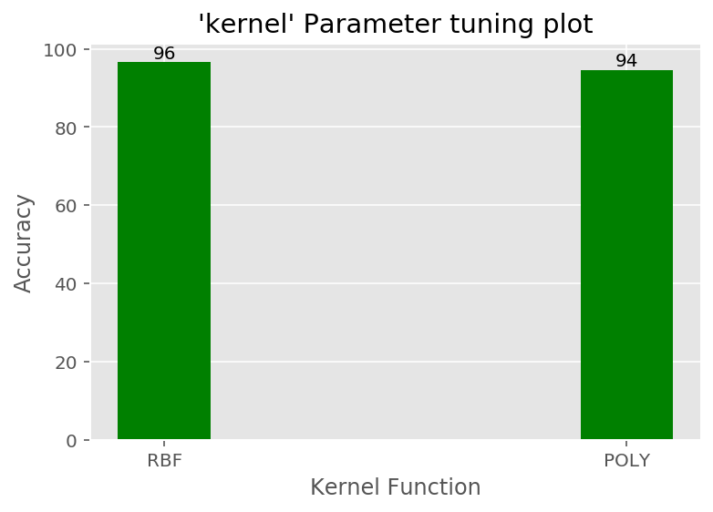

```python
svc_scores = [svc_roc_auc*100, poly_roc_auc*100]
svc_scores
Kernel = ["RBF", "POLY"]
bar1 = plt.bar(Kernel, svc_scores, width=0.2, align="center", color="green")
plt.xlabel("Kernel Function")
plt.ylabel("Accuracy")
plt.title("'kernel' Parameter tuning plot")
for rect in bar1:
    height = rect.get_height()
    plt.text(rect.get_x() + rect.get_width()/2.0 , height, '%d' % (height), ha='center', va='bottom')


plt.show()
```

```python
# for optimal kernel
optimal_kernel  = Kernel[svc_scores.index(max(svc_scores))]
optimal_auc_kernel = max(svc_scores)
```

#### Hyperparameter(2) Tuning - C

```
-> It is a Regularization parameter.
-> High C aims at classifying all training examples correctly.
```

```python
scores = []
C_values = range(1,100)

for c in C_values:
    svc = SVC(C = c)
    svc.fit(x_train, y_train)
    y_pred = svc.predict(x_test)
    false_positive_rate, true_positive_rate, thresholds = roc_curve(y_test, y_pred)
    svc_roc_auc = auc(false_positive_rate, true_positive_rate)
    svc_acc_per = round(svc_roc_auc*100, 3)
    scores.append(svc_acc_per)

best_results_svc = scores
```

```python
# For optimal C_value
optimal_auc_svc_c = max(scores)
optimal_c = C_values[scores.index(max(scores))]
```

```python
# training using optimal c-value.
svc = SVC(C = optimal_c)
svc.fit(x_train, y_train)
y_svc_pred = svc.predict(x_test)
```

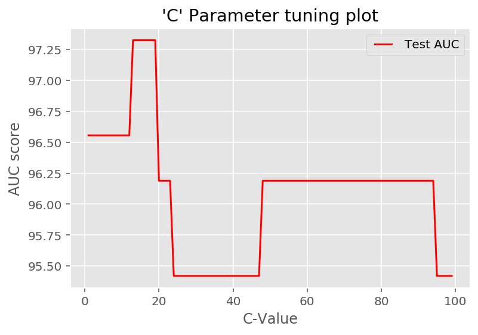

```python
from matplotlib.legend_handler import HandlerLine2D

line1, = plt.plot(C_values, scores, "r", label="Test AUC")
plt.legend(handler_map={line1: HandlerLine2D(numpoints=2)})
plt.title("'C' Parameter tuning plot")
plt.ylabel("AUC score")
plt.xlabel("C-Value")
plt.show()
```

#### Hyperparameter(2) Tuning - Gamma

```
-> Defines how much influence a single training example has.
```

```python
scoresHigh = []
scoresLow = []
gamma_high = range(1,10)
gamma_low =[]

for gamma in gamma_high:
    svc = SVC(gamma=gamma)
    svc.fit(x_train, y_train)
    y_pred = svc.predict(x_test)
    false_positive_rate, true_positive_rate, thresholds = roc_curve(y_test, y_pred)
    svc_roc_auc = auc(false_positive_rate, true_positive_rate)
    svc_acc_per = round(svc_roc_auc*100, 3)
    scoresHigh.append(svc_acc_per)

for gamma in gamma_high:
    svc = SVC(gamma = gamma/100)
    gamma_low.append(gamma/100)
    svc.fit(x_train, y_train)
    y_pred = svc.predict(x_test)
    false_positive_rate, true_positive_rate, thresholds = roc_curve(y_test, y_pred)
    svc_roc_auc = auc(false_positive_rate, true_positive_rate)
    svc_acc_per = round(svc_roc_auc*100, 3)
    scoresLow.append(svc_acc_per)
```

```python
#for optimal gamma

a= max(scoresHigh)
b = max(scoresLow)

if (a>b):
    index = scoresHigh.index(a)
    optimal_gamma = gamma_high[index]
    optimal_auc_svc_g = a
elif (b>a):
    index = scoresLow.index(b)
    optimal_gamma = gamma_low[index]
    optimal_auc_svc_g = b
```

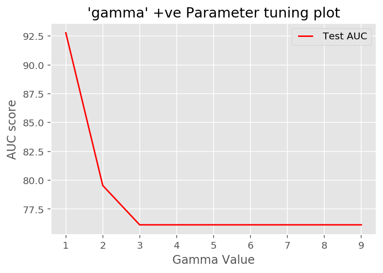

```python
from matplotlib.legend_handler import HandlerLine2D

line1, = plt.plot(gamma_high, scoresHigh, "r", label="Test AUC")
plt.legend(handler_map={line1: HandlerLine2D(numpoints=2)})
plt.title("'gamma' +ve Parameter tuning plot")
plt.ylabel("AUC score")
plt.xlabel("Gamma Value")
plt.show()
```

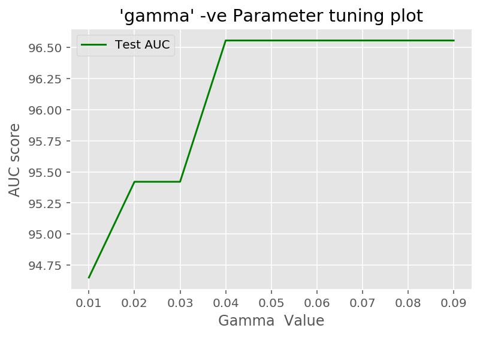

```python
from matplotlib.legend_handler import HandlerLine2D


line2, = plt.plot(gamma_low, scoresLow, "g", label="Test AUC")
plt.legend(handler_map={line1: HandlerLine2D(numpoints=2)})
plt.title("'gamma' -ve Parameter tuning plot")
plt.ylabel("AUC score")
plt.xlabel("Gamma  Value")
plt.show()
```

## Support Vector Classifier Evaluation:

```python
print()
print('\033[1m' + "Support Vector Classification Algorithm with Optimal Hyperparameter Configuration")
print("-----------------------------------------------------------------------")

print("|" , "Optimal Kernel" , " :", optimal_kernel ,   "|", round(optimal_auc_kernel, 2),'%', "|")
print("|", "Optimal C-Value", ":", optimal_c, " |", round(optimal_auc_svc_c,2),"%",  "|")
print("|", "Optimal Gamma", " :",optimal_gamma , "|", round(optimal_auc_svc_g, 2),"%",  "|")
```

```
Support Vector Classification Algorithm with Optimal Hyperparameter Configuration
-----------------------------------------------------------------------
| Optimal Kernel  : RBF | 96.56 % |
| Optimal C-Value : 13  | 97.32 % |
| Optimal Gamma  : 0.04 | 96.56 % |
```

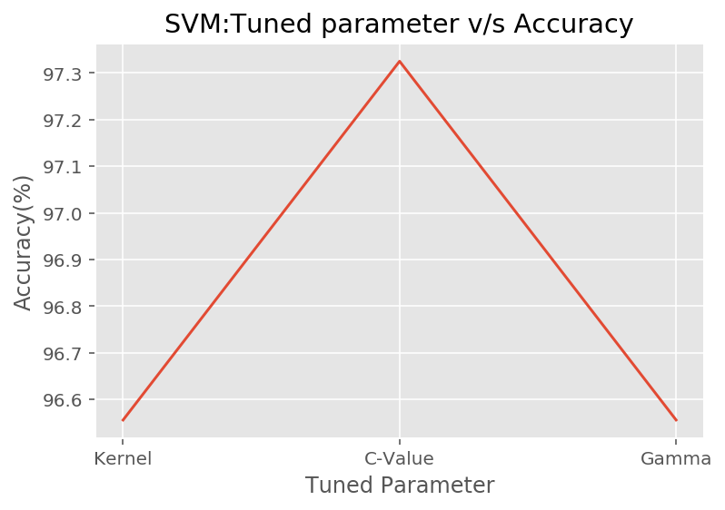

```python
plt.plot(["Kernel","C-Value","Gamma"],[optimal_auc_kernel,optimal_auc_svc_c,optimal_auc_svc_g])
plt.xlabel("Tuned Parameter")
plt.ylabel("Accuracy(%)")
plt.title("SVM:Tuned parameter v/s Accuracy")
plt.show()
```

```
- In Support Vector Classifier we observed highest accuracy of 97.32% with c_value = 13 and remaining default.
```